# Plotting_RVA_tutorial

Justin Pomeranz

# Overview

This tutorial will show you how to plot the range of variability approach (RVA) for the minimum 1-day flow and compare it with an experimental low flow from Glen Canyon Dam.

## Experimental Flows

We will be comparing the RVA to two different experimental flows

1. BUGS flows - Experimental low flows during summer weekends to improve macroinvertebrate community. [Link to news release](https://www.usbr.gov/newsroom/newsroomold/newsrelease/detail.cfm?RecordID=70708)
2. Experimental flood, April 2023. Aim was to improve sediment flow and movement and replenish sand bars. [NASA earth observatory article](https://earthobservatory.nasa.gov/images/151320/high-flow-at-glen-canyon-dam)

You will plot the empirical flow data in the `bug_flows` and `high-flow-2023` data sets, and compare it to the RVA for the min and max flows across 1-, 3-, and 7-day windows.

# Preliminaries

```r
library(tidyverse)
library(RcppRoll)
```

- If there was an error, make sure you have the `tidyverse` and `RcppRoll` packages downloaded onto your machine
- Remember you only need to install the packages once per machine, but you need to load them using the `library()` command every time you open RStudio.
- If needed, you can install the packages by running the following code: `install.packages("tidyverse")`, and `install.packages("RcppRoll")`, respectively. Make sure to re-run the `library()` commands above if needed.

## Load the data into R

If you have the correct file in your `data` folder, you can load it into R using the following command:

```r
pre <- read_tsv("data/pre_data.tsv")
bugs <- read_tsv("data/bug_flows.tsv")
```

- Check that the data was loaded correctly.

# need to fix date in bugs data

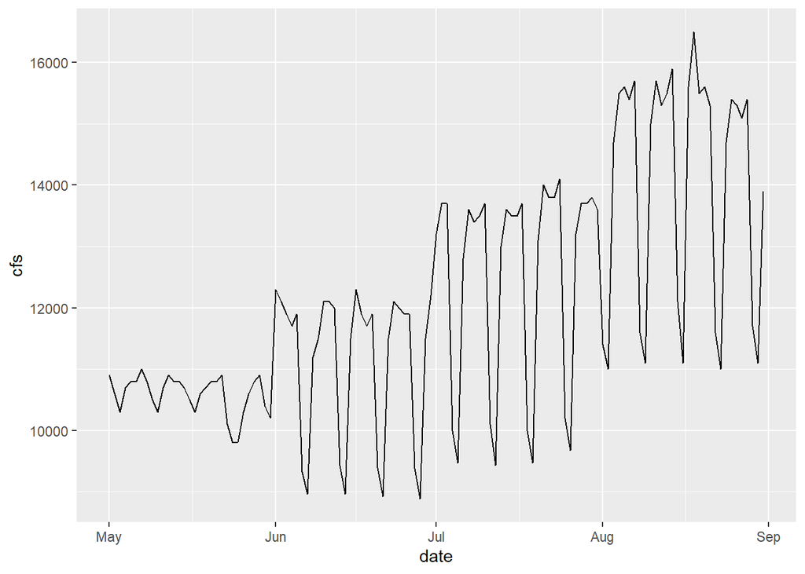

```r
bugs %>%
  ggplot(aes(x = date,
             y = cfs)) +
  geom_line()
```

### Group 2

- We will only be looking at the 1-day minimums in this tutorial.

#### 1-day values

Recall that the RVA for the 1-day minimums was calculated as follows:

```r
pre %>%
  group_by(y) %>%
  summarise(min_1 = min(cfs)) %>%
  summarise(m_min_1 = mean(min_1),
            # add sd() command here
            sd_min_1 = sd(min_1)) %>%
  pivot_longer(1:2,
               names_to = "metric",
               values_to = "value") %>%
  separate(1, c("stat", "metric", "day_window")) %>%
  pivot_wider(names_from = stat) %>%
  mutate(rva_low = m - sd,
         rva_high = m + sd) %>%
  select(metric, rva_low, rva_high)
```

```
## # A tibble: 1 × 3
##   metric rva_low rva_high
##   <chr>    <dbl>    <dbl>
## 1 min      1566.    3352.
```

This means that the RVA interval for the 1-day minimum flow is between 1,565 and 3,352 CFS.

We can now add reference lines to our original plot, and compare the RVA with what was actually observed.

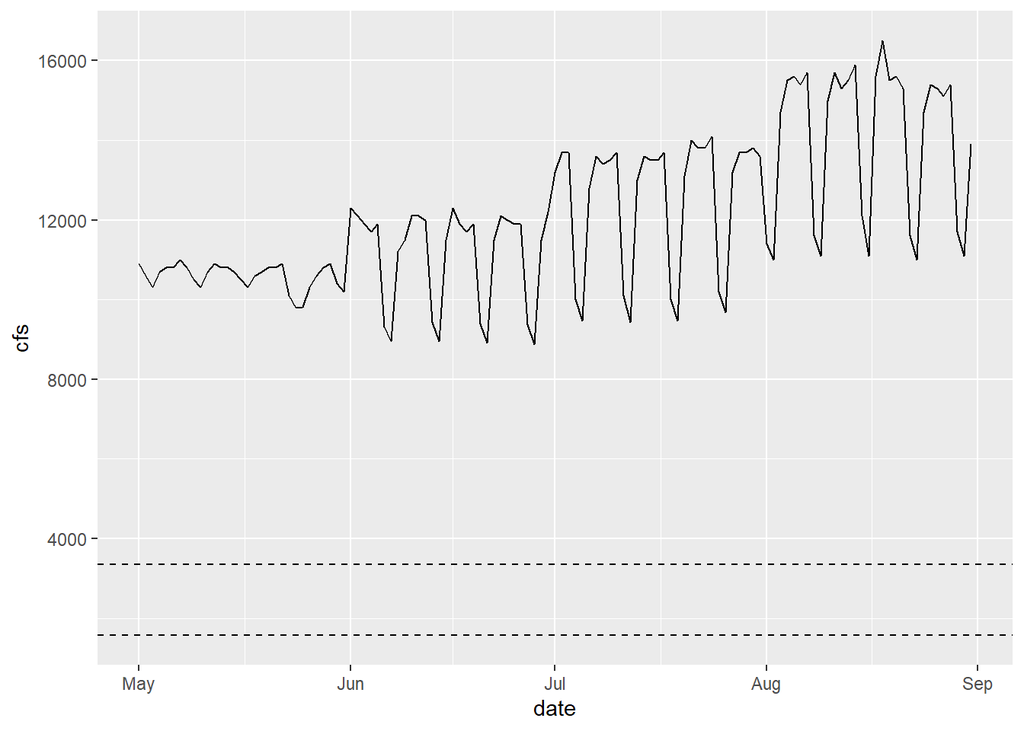

```r
bugs %>%
  ggplot(aes(x = date,
             y = cfs)) +
  geom_line() +
  geom_hline(aes(yintercept = 1565),
               linetype = "dashed") + # low interval
    geom_hline(aes(yintercept = 3352),
               linetype = "dashed")
```

Here, we can see that the experimental low flows were much higher than the RVA for the 1-day low flows.

### Hypothetical result

Just for comparison, and so you know what it looks like when our experimental flows *are* within the recommended RVA, here’s the plot of a hypothetical result. I’m also changing the `linetype` for illustrative purposes.

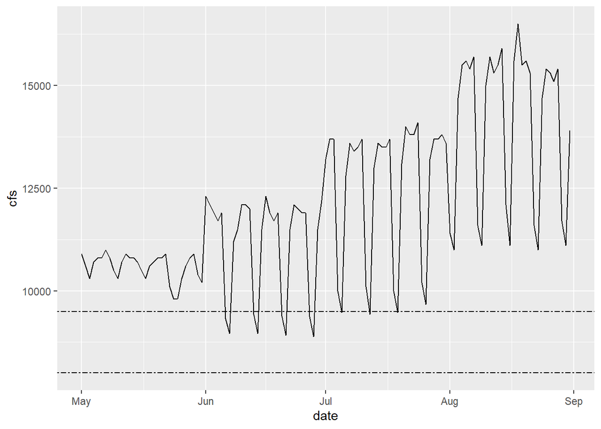

```r
bugs %>%
  ggplot(aes(x = date,
             y = cfs)) +
  geom_line() +
  geom_hline(aes(yintercept = 8000),
               linetype = "twodash") + # low interval
    geom_hline(aes(yintercept = 9500),
               linetype = "twodash")
```

Here, we can see that the first four low flows fall within the interval. It looks like the 5th-7th low flow also falls within the region, although we may need to “zoom in” to tell for sure.

#### “Zooming in”

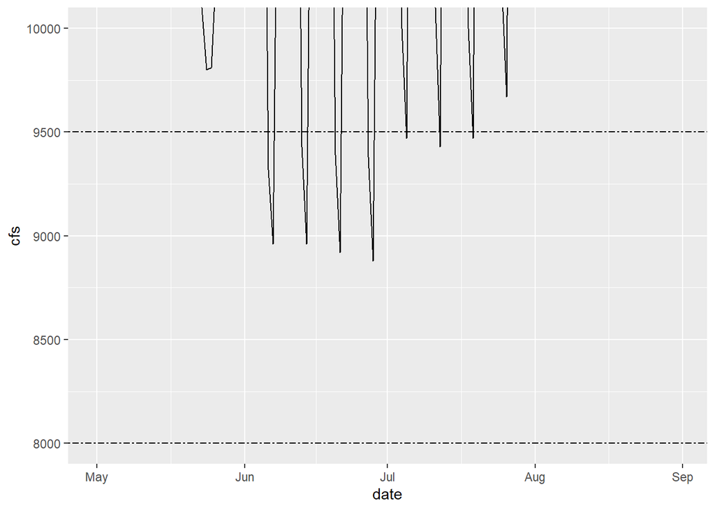

```r
bugs %>%
  ggplot(aes(x = date,
             y = cfs)) +
  geom_line() +
  geom_hline(aes(yintercept = 8000),
               linetype = "twodash") + # low interval
    geom_hline(aes(yintercept = 9500),
               linetype = "twodash") +
  coord_cartesian(ylim = c(8000, 10000))
```

It does appear that the 1st to 7th low-flows do fall within the RVA interval.

# Moving forward

## Complete part 4

### Minimum flows with `bugs` data

You will need to modify the code above to plot the RVA for the minimum flow in the 3- and 7-day windows.